# BIO 356 Lab 0: Introduction to R computing

Rafael D’Andrea** - Stony Brook University - Spring 2023

**In this lab you will learn that you can use R:**

1. As a calculator.
2. To read, analyze, and visualize data.
3. To write models and simulate data.
4. To output easy-to-read documents mixing regular text, R code, and R output.

**You will learn how to do the following things in R:**

- How to write the basic operations `+ - * / ^`
- Essential built-in R functions, such as `sqrt(), log(), exp(), mean(), var(), print()`.
- How to write custom functions in R.
- The basic data structures: vector, matrices, data frames, tibbles.
- Using the `tidyverse` package to handle data frames and make plots.
- Using conditional statements and for-loops.
- Generating random numbers.
- Knitting an R Markdown file to produce a PDF with text, code, and plots.

In this and all subsequent labs, the first thing you want to do is open RStudio and copy/paste to your RMarkdown file the code lines listing the libraries and themes to be used in the lab report (appearing in grey boxes below this paragraph). Then, run the code by clicking on the green triangle on the right side of the code blocks, OR by copy/pasting the code lines to the console and hitting Enter. This will load the R packages (a.k.a libraries) to your RStudio and set the theme (i.e. appearance) of the R plots that you will be making.

Once you’ve done this, you will be ready to start the lab.

```r
library(tidyverse)
library(rio) ## for dataset-reading function import()
```

```r
theme_set(theme_bw())
```

## Part 1

[figure not shown]

The following text, by Prof. Bret Larget at UW-Madison, explains why R is useful for you, an undergraduate student enrolled in a class whose title is not “Programming in R”:

> There are several reasons that make R an excellent choice of statistical software for an introductory statistical course. First, R is free and available on the Web. You can use it on your home computers and are not tied to campus labs. Second, R is powerful, widely-used software. The knowledge of R you gain during the course potentially translates to a marketable skill. You will learn to use a tool that has many practical uses outside the classroom. Third, even though it is not the simplest statistical software, the basics are easy enough to master that learning to use R need not interfere overly much with learning the statistical concepts encountered in an introductory course. Fourth, did I mention that it is free and you can use it at home?

You may have noticed these words are targeted to students enrolled in an Intro to Stats course. However, they are just as applicable to an Applied Ecology Lab audience.

While you do not need to become proficient in R to succeed in this class, knowing how to navigate the basics definitely helps. In this lab, we will practice some of the many R utilities that we will employ throughout the course. This lab will feel more technical and less ecological than you may have expected from this course. But bear with us, as getting this material down will make for smoother sailing going forward.

## R Markdown

As you will see in the sections below, R is a calculator + tool for statistical analysis + computing language for scientific modeling. However, we can also use R to generate formatted text that allows one person to read the work of another. This HTML file you are reading was compiled in RStudio from an RMarkdown file. RMarkdown (RMD) is a format that allows mixing regular text with R code and R output.

You can use the RMarkdwon file template provided on the course Blackboard site to complete your lab assignments. Just download the template, open it in RStudio, fill in the answers to the lab write-up questions, then “knit” it into a PDF file which you then submit to Blackboard.

Alternatively, if you prefer, you can complete your lab assignments in a Word document where you may copy/paste any R code or plots as needed.

An RMarkdown file will have a header that specifies the name of the file, the author, and the kind of output file it will produce (HTML, PDF, Word).

Below the header, you can type normal text. You can create section headings by using hashtags. You should answer each of the lab questions under a separate section heading. For each question you may include R code by using the code chunk syntax, which starts with three backtick signs ``` next to the lower case letter r inside curly brackets {r}, then another line starting with a set of three backticks, with your desired lines of R code placed in between them.

Here’s what a code chunk may look like on a RMarkdown file:

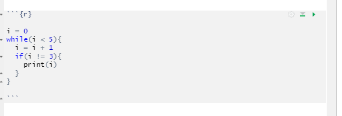

This covers the basics of how to work in an RMarkdown file. Make sure to check out the RMarkdown template on the course website. Once you download and open it, you can start working on this week’s lab assignment right now!

## Basic operations in R

The basic operations (addition, subtraction, multiplication, division) in R are all done as you would expect.

**Q1. Type the following lines in R and report the result of the mathematical expression.**

```r
12 * 3 - 10 / 2 + 16
```

**Q2. Repeat the operation above, but this time add a pair of parentheses. What do you get now?**

```r
12 * (3 - 10 / 2) + 16
```

**Note:** In R, spaces are purely aesthetic. You get the same result whether you write `12 * 3 - 10 / 2 + 16` or `12*3-10/2+16`, as you can verify for yourself.

Other common operations like exponentiation (raising a number to a power), square root, and the logarithm, are done using the symbol `^` and the functions `sqrt()`, `log()`.

**Q3. What is the result of the following expression:**

```r
2 ^ 3 - sqrt(16) + log(1)
```

**Note**: The caret symbol `^` raises a number to a power. Equivalently, you can use `**`. So for example `2 ^ 3 = 2 ** 3 = 8`.

While we can work directly with numbers as above, it is much more convenient to *assign* values to *variables* and work with the variables instead. In R, the assignment operator is the `=` symbol.

**Q4. Try the following code and report its result:**

```r
x = 12
y = 3
z = 10
w = 2
t = 16

x  * y - z / w + t
```

**Note:** You will find in some R texts assignments written using the symbol `<-` (meant to look like an arrow) rather than with the `=` sign. Those are interchangeable, so for example `x <- 12` is fully equivalent to `x = 12`. In this course we will largely be using the equal sign rather than the arrow.

**Q5. Just as the square root is the inverse function of squaring a number, the exponential function `exp()` is the inverse function of the logarithm. What is the result of `exp(log(x))`? Note: notice that the object name `x` was assigned the value of 12 in Q4. You can change that value to whatever you like. For example, you can write `x = 5` and then try `exp(log(x))`, then change it to something else and try `exp(log(x))` again.**

**Note:** Sometimes you may want to add text to your R code as a note to yourself or another human reader which you do not intend for R to process. This is called a *comment* in programming lingo. You can add a comment by prefacing it with the hash symbol, as exemplified in the following code

```r
x = 4

# x = 3. R will ignore this.

x
```

```
## [1] 4
```

## Functions

The text below about functions in R is reproduced with permission from Dr Gyorgi Barabás at Linköping University, Sweden.

A *function* in R can be thought of as a vending machine with inputs (coins of various denominations, plus the buttons you press for a particular item) and outputs (Mars bars, Coke, and the like). Except the inputs are called *arguments* instead of coins, and the output is called the *return value* instead of Red Bull, as illustrated in this bit of sophisticated art:

```
                             --------------
            Argument 1 ----> |            |
            Argument 2 ----> |  FUNCTION  | ----> Return Value
            Argument 3 ----> |            |
                             --------------
```

When you ask a function to do something, you’re *calling* the function. You’ve already called functions. Everything with a name followed by parentheses: `()`, possibly with things between the parentheses, is a function call: `sqrt()`, `exp()`, `sample()`, etc. When you type a function call at the R command line, R simply calls the function and displays the result on the next line. For example, when you execute `sqrt(9)`, you are calling the built-in *square root* function. Its argument (input) is 9, and its return value is the square root of 9, or 3.

Here is a way to automate calculating the area of a circle with radius `r`:

```r
circle_area = function(r) {
  area = r ^ 2 * pi
  return(area)
}
```

After executing the above lines, the computer now “knows” the function. Calling `circle_area(3)` will, for example, calculate the area of a circle with radius 3.

```r
circle_area(r = 3)
```

```
## [1] 28.27433
```

One can define functions with more than one argument. For instance, here is a function that calculates the area of a rectangle with sides `a` and `b`:

```r
rect_area = function(a, b) {
  area = a * b
  return(area)
}
```

```r
rect_area(2, 3)
```

```
## [1] 6
```

```r
rect_area(a = 2, b = 3)
```

```
## [1] 6
```

Notice how in either case we get the same result. Function arguments such as `a` and `b` in `rect_area()` can be called explicitly by name or implicitly by position.

**Note:** Any variables defined within a function (such as `area` above) are local to that function. So they are not visible from outside: even if `area` is defined within the function, one cannot access it from outside. You can test this by calling the object `area` on your console, and check out the error message you get.

**Q6. Given a triangle with sides *L1, L2, L3*, its area is calculated via the formula `Area = sqrt(p * (p - L1) * (p - L2) * (p - L3))`, where `p = (L1 + L2 + L3) / 2`. Write an R function called `tri_area` that outputs the area of a triangle given its sides, and calculate the area of a triangle with sides L1 = 3, L2 = 4, L3 = 5.**

## Data structures

### Vectors

So far we have been working with single numbers. However, when handling data we typically have a set of numbers to deal with. A *vector* is an example of a set of numbers. In R, we use the *concatenate* function `c()` to write vectors, as in the following example:

```r
v = c(3, 5, -2, 0, 1)
```

The object `v` is now a vector with five elements. If you now run `v` in the console (i.e. type `v` and hit enter), R will print the contents of the vector, namely, `3 5 -2 0 1`.

**Note:** If you don’t know how many elements a vector contains, you can use the function `length()` to find out. For example, if you run `length(v)`, R will print `5`.

**Q7. In R, we use square brackets `[ ]` to refer to specific elements of a vector. How would you look up the third element of vector v?**

**Note:** We can also subset any number of elements of `v`. For example, the code `v[c(4, 1)]` will get you the fourth and the first element of `v`, in that order (try it!).

**Q8. What does `v[2:4]` do? What do you deduce about the colon operator (`:`)? Test your hypothesis by running the command `1:10`, and then the command `10:1`.**

**Note:** Another way to write a series of consecutive integers is with the function `seq()`. The command `seq(a)` will write all integers between 1 and `a`, and the command `seq(a, b)` will write all integers between `a` and `b`.

R has the very convenient functionality of extending operations on numbers to operations on vectors in an easy and intuitive way. So for example if we type `2 * v`, we get

```
## [1]  6 10 -4  0  2
```

and if we type `10 ^ v`, we get

```
## [1] 1e+03 1e+05 1e-02 1e+00 1e+01
```

**Note:** The numbers above are written in scientific notation, where the letter `e` stands for *exponent* (not to be confused with the mathematical constant `e = 2.72` (Euler’s number), which is the base of the natural logarithm). So for example `1e+06 = 10 ^ 6 = 1,000,000` and `1e-02 = 1 / (10 ^ 2) = 0.01`. Back in **Q5** when you wrote `exp(log(x))`, the result is raising Euler’s number to the power `log(x)`, which results in `x`.

If we perform one of the basic operations between two vectors of equal length, R will compute the operation element-by-element:

```r
v1 = v
v2 = c(5, -1, -9, 2, 0)

v1 + v2
```

```
## [1]   8   4 -11   2   1
```

```r
v1 / v2
```

```
## [1]  0.6000000 -5.0000000  0.2222222  0.0000000        Inf
```

**Note:** What happens when you try to add two vectors of different length, such as `x1 = c(2, 3, 0)`, `x2 = c(1, -1)`? The answer is that R will perform the operation and issue a warning. Check it out! In general, watch out for unexpected results when you perform an operation between vectors of mismatching lengths.

We can also apply summarizing (i.e. statistical) functions to vectors, such as calculating the sum, product, mean, and variance of its elements:

```r
sum(v2)
```

```
## [1] -3
```

```r
prod(v1)
```

```
## [1] 0
```

```r
mean(v1)
```

```
## [1] 1.4
```

```r
var(v2)
```

```
## [1] 27.3
```

**Q9. What is the output of `mean(v1 + v2)`? How does that compare with the output of `sum(v1 + v2) / length(v1 + v2)`?**

The table below shows a list of commonly used functions in R that apply equally well to single numbers and vectors (after all, single numbers are vectors of length 1).

| Function | Meaning |
| --- | --- |
| `abs(x)` | absolute value |
| `sqrt(x)` | square root |
| `log(x)` | natural log |
| `log10(x)` | base-10 log |
| `exp(x)` | $e^x$ |
| `sum(x)` | sum all elements |
| `prod(x)` | multiply all elements |
| `mean(x)` | mean |
| `var(x)` | variance |
| `sd(x)` | standard deviation |
| `median(x)` | median |
| `quantile(x,q)` | compute the q-th quantile of x |
| `range(x)` | range of the data |
| `min(x)` | minimum |
| `max(x)` | maximum |
| `sort(x)` | sort the elements of x |
| `round(x,n)` | round to n decimal digits (default is n = 0) |

**Note:** One very helpful feature of R is that if you are not sure what a function does, you can look it up by typing `?function_name` or `help(function_name)` in the console in R or RStudio – or even by googling “function_name in R”. Try it out on the function `sign` by running `?sign`. Oftentimes, the help page will provde usage examples in the bottom, which are typically the most helpful part.

As you can see, R works with vectors in much the same way it does with single numbers. Other important data structures in R include *matrices*, *lists*, and *data frames*.

### Matrices

A matrix is essentially a two-dimensional vector. Here is one example:

```r
my_matrix = matrix(c(2, 7, -2.2, 0, 1, 1, -19, 3.3, -1), nrow = 3, ncol = 3)

my_matrix
```

```
##      [,1] [,2]  [,3]
## [1,]  2.0    0 -19.0
## [2,]  7.0    1   3.3
## [3,] -2.2    1  -1.0
```

Just like with a vector, you can look up a specific element of a matrix via its coordinates (row and column):

```r
my_matrix[3, 1]
```

```
## [1] -2.2
```

And you can even retrieve an entire row (or column) by simply leaving the corresponding coordinate blank:

```r
my_matrix[2, ]
```

```
## [1] 7.0 1.0 3.3
```

```r
my_matrix[, 3]
```

```
## [1] -19.0   3.3  -1.0
```

The same convenient element-by-element operations apply to matrices as they do to vectors. For example,

```r
my_other_matrix = my_matrix - 5

my_other_matrix
```

```
##      [,1] [,2]  [,3]
## [1,] -3.0   -5 -24.0
## [2,]  2.0   -4  -1.7
## [3,] -7.2   -4  -6.0
```

We will make extensive use of matrices in the module of our course that examines growth in age-structured populations.

**Q11. How would you create in R the following 3-by-2 matrix:**

```
##      [,1] [,2]
## [1,]    4    1
## [2,]   -2    1
## [3,]    0    7
```

### Lists

R can process non-numeric data as well. Other data types include character strings, logical values, and missing data. For example,

```r
my_dogs_age = 3.5
my_dogs_name = 'Hobbes'
my_cats_name = NA
is_my_dog_a_puppy = my_dogs_age < 1
```

```r
my_dogs_name
```

```
## [1] "Hobbes"
```

```r
my_cats_name
```

```
## [1] NA
```

```r
is_my_dog_a_puppy
```

```
## [1] FALSE
```

**Note:** Strings are always defined between single (’) or double (“) quotation marks.

**Note:** NA means not applicable or not available.

**NOte:** Another symbol you may see R print sometimes is `NaN`. That means “not a number”, and results when you try to perform an illegal mathematical operation, such as division by zero. For example, try running `0/0` in the console.

**Note:** The last line in the code chunk above, `is_my_dog_a_puppy = my_dogs_age < 1` may have confused you, because it is performing two operations at once: an *assignment*, and a *logical test*. The logical test operator `<` takes precedence over the assignment operator `=`. So R first tests whether `my_dogs_age` is less than 1, concludes that it is FALSE, and then assigns the value of FALSE to the name `is_my_dog_a_puppy`. The fact that the logical operator has precedence over the assignment operator is the reason why I didn’t need to add parentheses. But when in doubt, it is good practice to add parentheses”: the code line works equally and is easier for humans to parse if you write `is_my_dog_a_puppy = (my_dogs_age < 1)`.

**Note:** Remember, the logical test for equality in R is `==`, whereas the single `=` assigns values to object names. Sometimes when we want to check for equality between two objects `A` and `B`, we forget this and write `A = B`. This has a very different result than `A == B`.

**Q12. Find out what the function `str()` does by applying it to each of the variables defined above. Report and interpret your results.**

Notice, however, what happens when we try to concatenate the variables above into a single vector:

```r
my_pet_info = c(my_dogs_age, my_dogs_name, my_cats_name, is_my_dog_a_puppy)

my_pet_info
```

```
## [1] "3.5"    "Hobbes" NA       "FALSE"
```

```r
str(my_pet_info)
```

```
##  chr [1:4] "3.5" "Hobbes" NA "FALSE"
```

In trying to make a vector out of data of various types, we inadvertently created a vector where every element was turned into a character string.

The way to preserve the data structure is by creating a *list*:

```r
my_pet_info =
  list(
    my_dogs_age,
    my_dogs_name,
    my_cats_name,
    is_my_dog_a_puppy
  )

my_pet_info
```

```
## [[1]]
## [1] 3.5
##
## [[2]]
## [1] "Hobbes"
##
## [[3]]
## [1] NA
##
## [[4]]
## [1] FALSE
```

```r
str(my_pet_info)
```

```
## List of 4
##  $ : num 3.5
##  $ : chr "Hobbes"
##  $ : logi NA
##  $ : logi FALSE
```

**Note:** As with spaces, line breaks are purely aesthetic in R code.

We can retrieve an element of a list via double square brackets. For example,

```r
my_pet_info[[2]]
```

```
## [1] "Hobbes"
```

Lists (and also vectors) can have name attributes:

```r
my_dog_info =
  list(
    age = my_dogs_age,
    name = my_dogs_name,
    puppy = is_my_dog_a_puppy
  )
```

We can retrieve elements from named lists by name via a `$` sign:

```r
my_dog_info$name
```

```
## [1] "Hobbes"
```

**Q13. One of the useful features of R is that it gives specific error messages if something goes wrong. Test this by trying the command `2 * my_dog_info$name`. Explain the problem with attempting to do this. (To coerce RStudio to knit despite the error, add `error = TRUE` inside the heading of your code chunk – i.e make your code chunk heading read `{r error = TRUE}`)**

## Part 2

### Data frames

The last important data structure in our course is the *data frame*, which can be thought of as a table of data of various types.

One example of a data frame is the object `mtcars`, a built-in data set often used to illustrate R’s data analysis capabilities.

```r
mtcars
```

```
##                      mpg cyl  disp  hp drat    wt  qsec vs am gear carb
## Mazda RX4           21.0   6 160.0 110 3.90 2.620 16.46  0  1    4    4
## Mazda RX4 Wag       21.0   6 160.0 110 3.90 2.875 17.02  0  1    4    4
## Datsun 710          22.8   4 108.0  93 3.85 2.320 18.61  1  1    4    1
## Hornet 4 Drive      21.4   6 258.0 110 3.08 3.215 19.44  1  0    3    1
## Hornet Sportabout   18.7   8 360.0 175 3.15 3.440 17.02  0  0    3    2
## Valiant             18.1   6 225.0 105 2.76 3.460 20.22  1  0    3    1
## Duster 360          14.3   8 360.0 245 3.21 3.570 15.84  0  0    3    4
## Merc 240D           24.4   4 146.7  62 3.69 3.190 20.00  1  0    4    2
## Merc 230            22.8   4 140.8  95 3.92 3.150 22.90  1  0    4    2
## Merc 280            19.2   6 167.6 123 3.92 3.440 18.30  1  0    4    4
## Merc 280C           17.8   6 167.6 123 3.92 3.440 18.90  1  0    4    4
## Merc 450SE          16.4   8 275.8 180 3.07 4.070 17.40  0  0    3    3
## Merc 450SL          17.3   8 275.8 180 3.07 3.730 17.60  0  0    3    3
## Merc 450SLC         15.2   8 275.8 180 3.07 3.780 18.00  0  0    3    3
## Cadillac Fleetwood  10.4   8 472.0 205 2.93 5.250 17.98  0  0    3    4
## Lincoln Continental 10.4   8 460.0 215 3.00 5.424 17.82  0  0    3    4
## Chrysler Imperial   14.7   8 440.0 230 3.23 5.345 17.42  0  0    3    4
## Fiat 128            32.4   4  78.7  66 4.08 2.200 19.47  1  1    4    1
## Honda Civic         30.4   4  75.7  52 4.93 1.615 18.52  1  1    4    2
## Toyota Corolla      33.9   4  71.1  65 4.22 1.835 19.90  1  1    4    1
## Toyota Corona       21.5   4 120.1  97 3.70 2.465 20.01  1  0    3    1
## Dodge Challenger    15.5   8 318.0 150 2.76 3.520 16.87  0  0    3    2
## AMC Javelin         15.2   8 304.0 150 3.15 3.435 17.30  0  0    3    2
## Camaro Z28          13.3   8 350.0 245 3.73 3.840 15.41  0  0    3    4
## Pontiac Firebird    19.2   8 400.0 175 3.08 3.845 17.05  0  0    3    2
## Fiat X1-9           27.3   4  79.0  66 4.08 1.935 18.90  1  1    4    1
## Porsche 914-2       26.0   4 120.3  91 4.43 2.140 16.70  0  1    5    2
## Lotus Europa        30.4   4  95.1 113 3.77 1.513 16.90  1  1    5    2
## Ford Pantera L      15.8   8 351.0 264 4.22 3.170 14.50  0  1    5    4
## Ferrari Dino        19.7   6 145.0 175 3.62 2.770 15.50  0  1    5    6
## Maserati Bora       15.0   8 301.0 335 3.54 3.570 14.60  0  1    5    8
## Volvo 142E          21.4   4 121.0 109 4.11 2.780 18.60  1  1    4    2
```

In a data frame, the rows typically constitute data observations (datapoints) and the columns list the various attributes of each datapoint. In the example above, the data comprises 11 aspects of car design and performance of 32 cars, obtained from a 1974 issue of Motor Trend US magazine.

We can explicitly ask R what type of object `mtcars` is by typing

```r
str(mtcars)
```

```
## 'data.frame':    32 obs. of  11 variables:
##  $ mpg : num  21 21 22.8 21.4 18.7 18.1 14.3 24.4 22.8 19.2 ...
##  $ cyl : num  6 6 4 6 8 6 8 4 4 6 ...
##  $ disp: num  160 160 108 258 360 ...
##  $ hp  : num  110 110 93 110 175 105 245 62 95 123 ...
##  $ drat: num  3.9 3.9 3.85 3.08 3.15 2.76 3.21 3.69 3.92 3.92 ...
##  $ wt  : num  2.62 2.88 2.32 3.21 3.44 ...
##  $ qsec: num  16.5 17 18.6 19.4 17 ...
##  $ vs  : num  0 0 1 1 0 1 0 1 1 1 ...
##  $ am  : num  1 1 1 0 0 0 0 0 0 0 ...
##  $ gear: num  4 4 4 3 3 3 3 4 4 4 ...
##  $ carb: num  4 4 1 1 2 1 4 2 2 4 ...
```

which reveals that it is a `data.frame` object with 32 observations (32 cars) of 11 car attributes.

The commands `rownames()` and `colnames()` will give us respectively the names of the rows – in this example, each car model – and columns – each car attribute, such as fuel consumption in miles per gallon (mpg) and number of cylinders (cyl).

In a data frame, we can retrieve a column using `$`.

**Q14. What will the command `mean(mtcars$mpg)` return? Give the value and explain its meaning.**

**Q15. How would you calculate the variance in the number of cylinders across all cars?**

## Tidyverse

Throughout the course we will use the suite of R packages called *tidyverse*, designed to standardize and facilitate the processing and analysis of data frames in R.

You have already installed the tidyverse suite, and you can load it by typing `library(tidyverse)`. In fact, the first thing to do at the beginning of each lab section in the course will be to run the code lines at the top of the write-up which load all of the packages (a.k.a. libraries) that will be used in that lab.

Coding in the tidyverse is analogous to writing “sentences” with “nouns” (data structures such as vectors and data frames) and “verbs” (operations on data structures, i.e. functions which receive as input a data structure). Once you get the hang of this grammar, you may find it very intuitive to manipulate data in R.

We connect the nouns and verbs using the *pipe* symbol `|>` (or equivalently the older pipe symbol `%>%`). Here is an example of a short sentence that turns the row names of `mtcars` into a column called *model* using the verb `rownames_to_column()`:

```r
car_dataframe =
  mtcars |>
  rownames_to_column(var = 'model')

car_dataframe
```

```
##                  model  mpg cyl  disp  hp drat    wt  qsec vs am gear carb
## 1            Mazda RX4 21.0   6 160.0 110 3.90 2.620 16.46  0  1    4    4
## 2        Mazda RX4 Wag 21.0   6 160.0 110 3.90 2.875 17.02  0  1    4    4
## 3           Datsun 710 22.8   4 108.0  93 3.85 2.320 18.61  1  1    4    1
## 4       Hornet 4 Drive 21.4   6 258.0 110 3.08 3.215 19.44  1  0    3    1
## 5    Hornet Sportabout 18.7   8 360.0 175 3.15 3.440 17.02  0  0    3    2
## 6              Valiant 18.1   6 225.0 105 2.76 3.460 20.22  1  0    3    1
## 7           Duster 360 14.3   8 360.0 245 3.21 3.570 15.84  0  0    3    4
## 8            Merc 240D 24.4   4 146.7  62 3.69 3.190 20.00  1  0    4    2
## 9             Merc 230 22.8   4 140.8  95 3.92 3.150 22.90  1  0    4    2
## 10            Merc 280 19.2   6 167.6 123 3.92 3.440 18.30  1  0    4    4
## 11           Merc 280C 17.8   6 167.6 123 3.92 3.440 18.90  1  0    4    4
## 12          Merc 450SE 16.4   8 275.8 180 3.07 4.070 17.40  0  0    3    3
## 13          Merc 450SL 17.3   8 275.8 180 3.07 3.730 17.60  0  0    3    3
## 14         Merc 450SLC 15.2   8 275.8 180 3.07 3.780 18.00  0  0    3    3
```

[output cut: 18 more lines]

It is useful to store the results of our work in an object which we can later call at any time, as we did above. This is easily done using the assignment symbol `=` on top of the sentence. In plain English, the coding sentence above reads “Take the data frame `mtcars`, turn its row names into a column called *model*, then assign the resulting data frame to an object called `car_dataframe`.

While data frames are very useful objects in R, tidyverse introduces a very similar data structure called *tibble* (a play on *table*), which is exactly like a dataframe but with smarter printing properties. We can turn a regular data frame object into a tibble with the verb `as_tibble()`:

```r
car_tibble =
  car_dataframe |>
  as_tibble()

car_tibble
```

```
## # A tibble: 32 × 12
##    model         mpg   cyl  disp    hp  drat    wt  qsec    vs    am  gear  carb
##    <chr>       <dbl> <dbl> <dbl> <dbl> <dbl> <dbl> <dbl> <dbl> <dbl> <dbl> <dbl>
##  1 Mazda RX4    21       6  160    110  3.9   2.62  16.5     0     1     4     4
##  2 Mazda RX4 …  21       6  160    110  3.9   2.88  17.0     0     1     4     4
##  3 Datsun 710   22.8     4  108     93  3.85  2.32  18.6     1     1     4     1
##  4 Hornet 4 D…  21.4     6  258    110  3.08  3.22  19.4     1     0     3     1
##  5 Hornet Spo…  18.7     8  360    175  3.15  3.44  17.0     0     0     3     2
##  6 Valiant      18.1     6  225    105  2.76  3.46  20.2     1     0     3     1
##  7 Duster 360   14.3     8  360    245  3.21  3.57  15.8     0     0     3     4
##  8 Merc 240D    24.4     4  147.    62  3.69  3.19  20       1     0     4     2
##  9 Merc 230     22.8     4  141.    95  3.92  3.15  22.9     1     0     4     2
## 10 Merc 280     19.2     6  168.   123  3.92  3.44  18.3     1     0     4     4
## # … with 22 more rows
```

Notice how compared to `car_dataframe`, when we print `car_tibble` we get explicit information on the number of rows and columns contained in the data, plus the type of data in each column: character (chr) for column *model*, then numeric for all other columns (dbl, for double-precision floating point, which is just programming jargon for a real number). Also, rather than printing the whole thing, R prints what fits comfortably on screen that can be examined at a glance.

**Note:** Everything you can do on a `data.frame` object can also be done on a `tibble` object and vice-versa. We will work with tibbles because they print more smartly.

It is just as easy to create a brand new tibble from scratch using the function `tibble()`:

```r
characters =
  tibble(
    name = c('Calvin', 'Hobbes', 'Garfield', 'Popeye', 'Bugs Bunny', 'Lisa Simpson', 'Woodstock'),
    species = c('human', 'tiger', 'cat', 'human', 'rabbit', 'human', 'canary'),
    comic_strip = c(TRUE, TRUE, TRUE, TRUE, FALSE, FALSE, TRUE)
  )

characters
```

```
## # A tibble: 7 × 3
##   name         species comic_strip
##   <chr>        <chr>   <lgl>
## 1 Calvin       human   TRUE
## 2 Hobbes       tiger   TRUE
## 3 Garfield     cat     TRUE
## 4 Popeye       human   TRUE
## 5 Bugs Bunny   rabbit  FALSE
## 6 Lisa Simpson human   FALSE
## 7 Woodstock    canary  TRUE
```

We can add new columns using the verb `mutate()`:

```r
characters =
  characters |>
  mutate(year_created = c(1985, 1985, 1978, 1929, 1940, 1987, 1967))

characters
```

```
## # A tibble: 7 × 4
##   name         species comic_strip year_created
##   <chr>        <chr>   <lgl>              <dbl>
## 1 Calvin       human   TRUE                1985
## 2 Hobbes       tiger   TRUE                1985
## 3 Garfield     cat     TRUE                1978
## 4 Popeye       human   TRUE                1929
## 5 Bugs Bunny   rabbit  FALSE               1940
## 6 Lisa Simpson human   FALSE               1987
## 7 Woodstock    canary  TRUE                1967
```

We can select a subset of the columns in a tibble and rearrange them in any order we want using the verb `select()`:

```r
characters |>
  select(name, year_created, species)
```

```
## # A tibble: 7 × 3
##   name         year_created species
##   <chr>               <dbl> <chr>
## 1 Calvin               1985 human
## 2 Hobbes               1985 tiger
## 3 Garfield             1978 cat
## 4 Popeye               1929 human
## 5 Bugs Bunny           1940 rabbit
## 6 Lisa Simpson         1987 human
## 7 Woodstock            1967 canary
```

Another important verb is `filter()`, which allows you to keep only the datapoints you are interested in, i.e. only the rows that satisfy a specified condition:

```r
characters |>
  filter(species != 'human')
```

```
## # A tibble: 4 × 4
##   name       species comic_strip year_created
##   <chr>      <chr>   <lgl>              <dbl>
## 1 Hobbes     tiger   TRUE                1985
## 2 Garfield   cat     TRUE                1978
## 3 Bugs Bunny rabbit  FALSE               1940
## 4 Woodstock  canary  TRUE                1967
```

**Q16. By piping the verb `arrange()`, write code that prints the `characters` tibble with rows arranged by the year the character was created. (Hint: just put the name of the column inside the verb)**

```r
new_car_tibble =
  mtcars |>
  rownames_to_column(var = 'model') |>
  as_tibble() |>
  mutate(kml = mpg * 0.43) |>
  select(model, kml, cyl) |>
  filter(cyl == 4, kml > 10) |>
  arrange(kml)
```

Let’s unpack the code chunk above.

- We assign the name `new_car_tibble` to an object created as follows:
- First, take the built-in data frame `mtcars`,
- next, convert its row names to a new column named *model*,
- then, convert the whole object into a tibble,
- then, create a new column named *kml* (kilometers per liter) by multiplying mpg by 0.43 (as 1 mile per gallon = 0.43 kilometers per liter),
- then, select only the columns *model*, *kml*, and *cyl* (number of cylinders),
- then, we filter the tibble to keep only the cars with 4 cylinders and fuel efficiency $>$ 10 km/liter,
- finally, arrange the cars by fuel efficiency.

We can inspect the resulting tibble by calling it:

```r
new_car_tibble
```

```
## # A tibble: 7 × 3
##   model            kml   cyl
##   <chr>          <dbl> <dbl>
## 1 Merc 240D       10.5     4
## 2 Porsche 914-2   11.2     4
## 3 Fiat X1-9       11.7     4
## 4 Honda Civic     13.1     4
## 5 Lotus Europa    13.1     4
## 6 Fiat 128        13.9     4
## 7 Toyota Corolla  14.6     4
```

As you can see, a sentence in tidyverse can have as many pipes as we want. In fact, the idea behind naming the symbol `|>` *pipe* is that you have information flowing down a pipeline. The piping structure allows R to apply an indefinite number of verbs on a data structure in order, and makes it easy to follow what is being done in each code line.

**Note:** Notice how the verb `mutate()` can be used to create new columns from scratch, as we did in the `characters` tibble, or based on existing ones, as we just did above.

**Note:** We can impose any number of filters at once on a single line, as we just did above when filtering at the same time for a specified number of cylinders and minimum fuel efficiency.

**Q17. Write R code that creates an object called `my_tibble` in a single pipeline that starts with `mtcars`, then**

1. **converts its row names to a column named “model”**
2. **converts the data frame to a tibble**
3. **selects columns *model, mpg, cyl, hp***
4. **creates a column called *kml* corresponding to the converted *mpg***
5. **filters only cars with mpg > 22**

In addition to `mutate()`, `select()`, `filter()`, and `arrange()`, the tidyverse contains many more useful verbs for manipulating data. We will not be exploring them here but they will appear in the upcoming labs.

**Note:** If the content so far has seem overwhelming and you are wondering how you are going to recall all of this, don’t worry! This is not a programming course, and going forward you will not be required to come up with code to make R do things. Rather, you will be copy/pasting code that will be provided to you. This introduction is meant for you to have a sense of what the provided code is doing.

## Reading data

So far we have been working with a built-in data set, `mtcars`. However, in most cases of interest we will want to read data from an external source, such as an online data repository. R has a number of functions to read external data. You will not need to know how to use those functions, as the code for reading the data set in question will always be provided to you in this course.

The following is one such example of importing a data set from an external source. In this case the external source is my BIO 356 GitHub page, and the data set shows estimates of the eastern North Pacific population of gray whales based on whale sightings off the coast of California between 1968 and 2002.

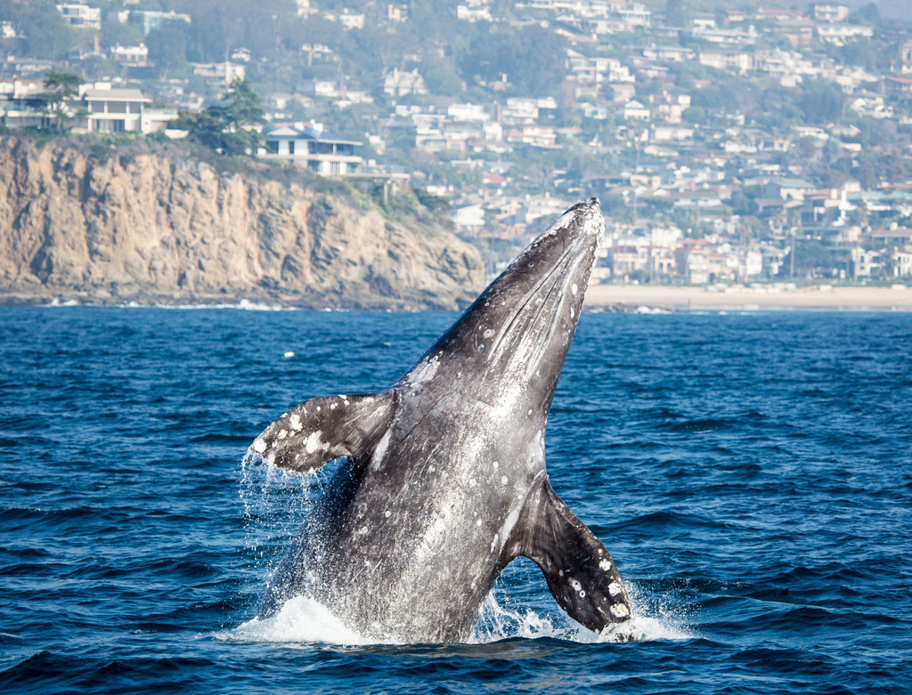

Figure: Gray whale (*Eschrichtius robustus*) breaching in San Diego, CA. Photo credit: lajolla.com

```r
github_address = 'https://github.com/rafaeldandrea/BIO-356/blob/master/gray_whales.xlsx?raw=true'

whale_dataset =
  rio::import(github_address, range = 'B6:G28') |>
  as_tibble()
```

- The first line of code creates a string object called `github_address`, containing the URL where the data set is stored.
- I then create an object called `whale_dataset` which first imports the data set using that address via the function (verb) `import()` from R package “rio” (which you already installed on your computer along with all other required packages for the course, and loaded it above when you copy/pasted all libraries from this week’s write-up).
- Finally, I convert the data set to a tibble so we can easily visualize the data.

**Note:** The double-colon symbol `::` tells R explicitly where to look for a function. This is useful in cases where more than one R package contain functions with the same name, or when you are not sure whether you already loaded the R package in question. The usage is always `package_name::function_name`.

Let’s look at our newly imported data:

```r
whale_dataset
```

```
## # A tibble: 22 × 6
##    End_dates           Cited_abundance    SE Source New_abundance New_SE
##    <dttm>                        <dbl> <dbl>  <dbl>         <dbl>  <dbl>
##  1 1968-02-03 00:00:00           12921   964     NA         13776   1082
##  2 1969-02-06 00:00:00           12070   594     NA         12869    708
##  3 1970-02-08 00:00:00           12597   640      1         13431    758
##  4 1971-02-12 00:00:00           10707   487      1         11416    590
##  5 1972-02-07 00:00:00            9760   524     NA         10406    614
##  6 1973-02-16 00:00:00           15099   688     NA         16098    834
##  7 1974-02-08 00:00:00           14696   731      1         15960    872
##  8 1975-02-07 00:00:00           12955   659      1         13812    781
##  9 1976-02-03 00:00:00           14520   796      1         15481    930
## 10 1977-02-06 00:00:00           15304   669      1         16317    818
## # … with 12 more rows
```

The data set above contains 22 entries organized by calendar date, each of which contains an estimate for the whale population size in that year. For simplicity, we can just focus on the *End_dates* column and the *New_abundance* and *New_SE* columns, which provide the researchers’ best guesses for the yearly population size and the uncertainty on that quantity.

**Q18. What is the estimated whale population in February of 1973? What is the uncertainty on that estimate? Note: no code needed here. Just inspect the table visually and find the appropriate numbers.**

## Plotting

In addition to reading and manipulating data, we often want to visualize our data using plots. The tidyverse environment in R has a whole grammar for making plots, into which we will dip our toes here. Again, you are not required to master this so-called *grammar of graphics*, as the code for plotting things will always be provided to you. Rather, you will often be asked to tweak provided code to modify a given plot, so what you want is to be able to understand the gist of provided code.

Let’s use the whale data set above to make some plots.

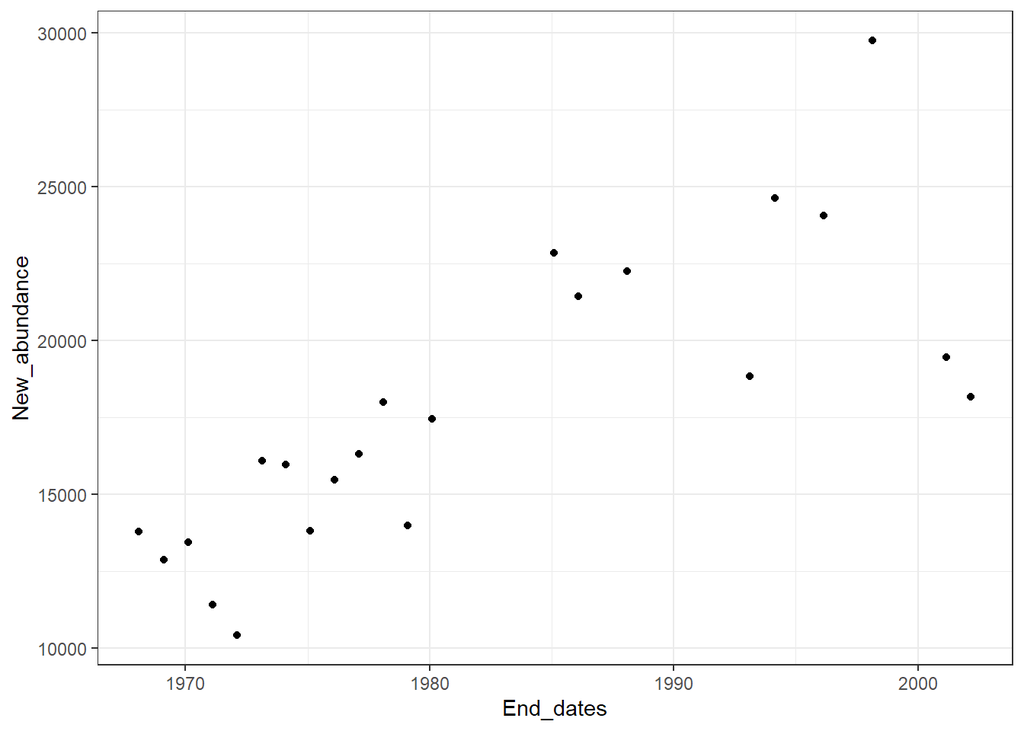

```r
plot_whales =
  whale_dataset |>
  ggplot(aes(End_dates, New_abundance)) +
  geom_point()

plot_whales
```

The scatter plot above shows abundance estimates on the y-axis and dates on the x-axis. We follow the same type of noun-and-verbs pipeline as we were doing above when manipulating tibbles. We start with the `whale_dataset` object, then pipe in the verb `ggplot()`, which tells R that everything that will follow are verbs that apply to graphic objects. Indeed, after the verb `ggplot()` we pipe in the verb `geom_point()`, which tells R to make a plot where the datapoints are represented by dots.

You will notice that inside the verb `ggplot()` we have `aes(End_dates, New_abundance)`. This is what tells R what to plot on the x-axis (i.e. the horizontal axis) and what to plot on the y-axis (i.e. the vertical axis). The syntax here is always `ggplot(aes(column_name_1, column_name_2))`, where *column_name_1* will be plotted on the x-axis and *column_name_2* on the y-axis. Then once we pipe in the verb `geom_point()`, R already knows what is going on each axis and simply draws the points. The whole thing is then stored in the object `plot_whales`, and the plot is actually drawn on your screen once you call the object.

**Note:** Sadly, the developers of this system decided to use the addition symbol `+` to pipe together plot-oriented verbs rather than the `|>` pipe symbol used for tibbles. It would have been nice if we could just stick to a single unified pipe symbol for all objects in R, but you can’t have everything.

What if we wanted to connect the dots? R has the verb `geom_line()` for that. You can just pipe it into the `plot_whales` object, as follows:

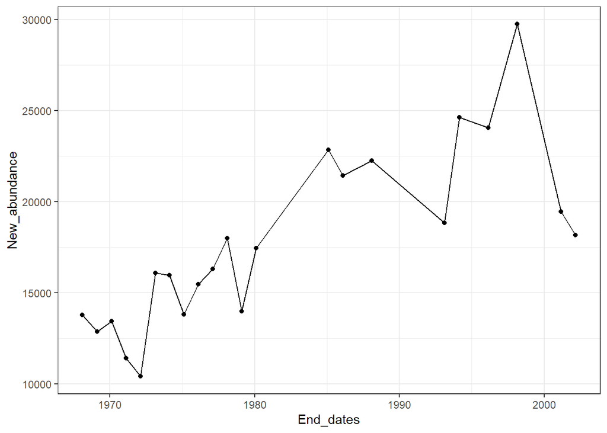

```r
plot_whales +
  geom_line()
```

**Q19. What do we get if instead of creating the object `plot_whales` without the connecting lines and then piping in `geom_line()` as we just did above, we define the object with the `geom_line()` verb piped into it directly? Show R code that does this, then make your plot.**

This is the basic tidyverse way of constructing plots from data sets in R. We can do much more by just piping in more verbs, and by modifying the arguments inside the verbs from their default values. For example,

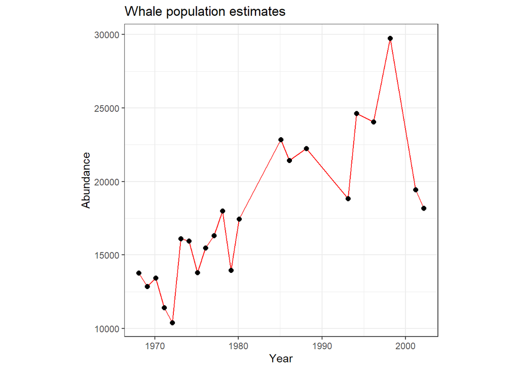

```r
plot_whales =
  whale_dataset |>
  ggplot(aes(End_dates, New_abundance)) +
  geom_line(color = 'red') +
  geom_point(size = 2) +
  labs(
    x = 'Year',
    y = 'Abundance'
  ) +
  theme(aspect.ratio = 1) +
  ggtitle('Whale population estimates')

plot_whales
```

In the code above, after adding `geom_point()` which draws the dots and `geom_line()` which draws the connecting line, we added `labs()`, which lets us change the labels on the axes, `theme()` which lets us change many different aspects of the plot – here, the overall shape of the plot, which I made square by setting `aspect.ratio = 1` – and then added `ggtitle()`, which prints a name for the plot on top.

Notice that I changed the color of the connecting line to red by setting the argument `color = "red"` inside `geom_line()`, and the size of the dots by setting the argument `size = 2` in `geom_point()`, and I changed the order of `geom_line()` and `geom_point()` which puts the dots in front of the line since they are drawn after the line. The latter illustrates the flexibility of this piping system with regards to the order of the verbs.

What if we want to add error bars? Not a problem:

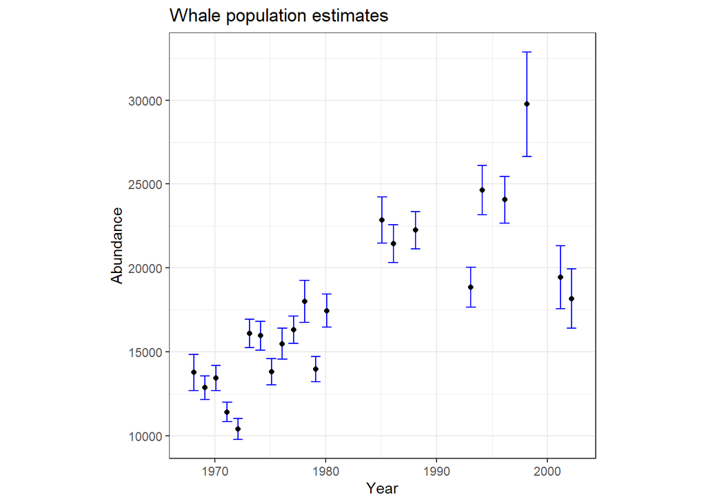

```r
plot_whales =
  whale_dataset |>
  ggplot(aes(End_dates, New_abundance)) +
  geom_errorbar(
    aes(
      x = End_dates,
      ymin = New_abundance + New_SE,
      ymax = New_abundance - New_SE
    ),
    color = 'blue'
  ) +
  geom_point() +
  labs(
    x = 'Year',
    y = 'Abundance'
  ) +
  theme(aspect.ratio = 1) +
  ggtitle('Whale population estimates')

plot_whales
```

In the plot above we used the column *New_SE* in the data set to draw the error bars. Notice how the verb `geom_errorbar()` needs an argument `aes()` similar to the one in `ggplot()`, and inside that argument we provide information on what should go on the x-axis (*End_dates*), and what should be the minimum and maximum values on the y-axis. I also removed the connecting line so the plot doesn’t get too busy.

**Q20. Replicate the plot above, but this time change the color of the dots to red, the x and y labels to “Calendar year” and “Population size”, and bring back the connecting line, colored green (keep the error bars).**

Another useful element to a scatter plot is a *trend line*, which we can add to the plot by piping in the verb `geom_smooth()`

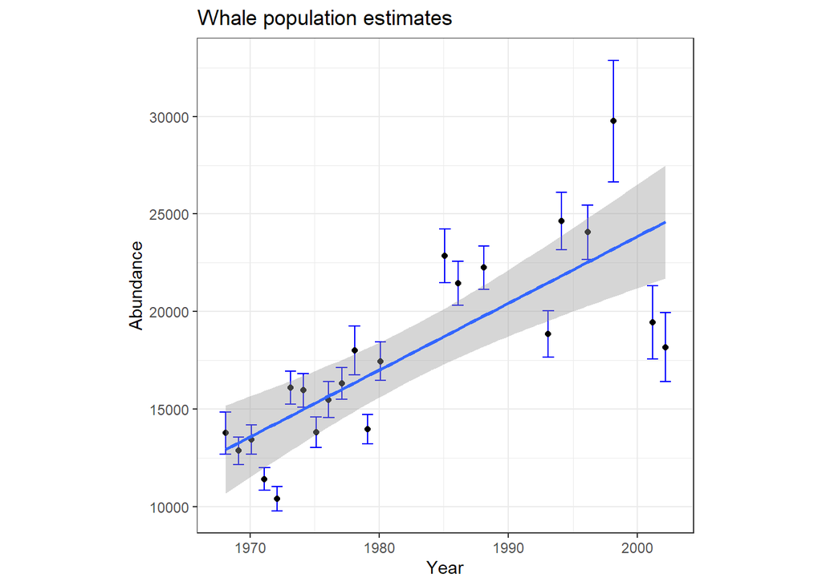

```r
plot_whales +
  geom_smooth(method = 'lm')
```

In the case above, we used a linear model (lm) to set the trend line. The line shows the rising trend in the whale population, and the grey band shows the uncertainty in the trend.

In the remaining labs of this course you will see many plots like these. Upon completing this lab you should be able to follow and edit the code provided, as in **Q20**.

## Control flow

In ecology, we often have data sets that we want to use to answer ecological questions such as “Is the population of eastern North Pacific gray whales increasing?”. As we have seen so far, R is excellent at reading, wrangling, and visualizing data such that we can easily get our answers to questions like these.

However, a lot of times ecologists want to make predictions about what has not yet been seen. What are the chances that gray whales will go extinct within 50 years, given what we know about their population over the past 30 years? How much of a rise in global temperatures should we expect within the next 20 years? What is the expected human population in 100 years? To answer questions like these, ecologists may use simulated data (since we can’t observe the future!), which in turn is obtained using models and computers.

While so far we have been emphasizing R as a tool of statistical analysis, next we will look at its usefulness as a tool for generating simulated data.

Computers are famous for speed and automation. In other words, they can repeateadly perform many calculations fast. In any computing language, this is ultimately done via *control flow* structures such as *conditional statements* and *for-loops*. Here we will look at how to use them in R.

### Conditional statements

Conditional statements are also called *if-statements*, and they rely on logical tests.

Here’s a simple logical test in R

```r
2 > 3
```

```
## [1] FALSE
```

We get a result of FALSE, which is a logical object. In R, the function `if()` receives as an argument a logical object and returns an action that the user specifies. This is what an if-statement is. Here’s an example if-statement in R:

```r
if(2 > 3){
  print('Two is greater than three')
}
```

When you enter the code above, nothing happens because R ignores what is inside the curly brackets `{}` since the argument of the `if()` function was FALSE.

We can also tell R what to do in case the logical test returns FALSE:

```r
if(2 > 3){
  print('Two is greater than three')
} else {
  print('Two is NOT greater than three')
}
```

```
## [1] "Two is NOT greater than three"
```

In this piece of (hopefully) simple and intuitive code, R tests whether 2 > 3, concludes that this is FALSE, and then skips what is inside the curly brackets (since the argument of `if()` was FALSE), then finds an `else` statement, which tells it what to do in case the first test was FALSE. This is the R syntax for if-else expressions.

We can refine the code some more:

```r
if(2 > 3){
  print('Two is greater than three')
} else if(2 == 3){
  print('Two is equal to three')
} else {
  print('Two is less than three')
}
```

```
## [1] "Two is less than three"
```

The code above introduces the `else if` structure, which allows you to ask about more than two possible options (2 can be greater than, equal to, or less than 3).

**Note:** Note that when checking whether 2 is equal to three, we use the double `==` sign, not the single `=` sign. The difference is that when doubled, the equal signs represent a logical test (we are checking if two things are equal), while the single equal sign is the assignment symbol (we are assigning a value to an object). So for example the code `x = 2` tells R to assign the value 2 to an object called `x` (if `x` already existed and had a different value, that will now be overwritten to 2), whereas the code `x == 2` tests whether it is true that the value assigned to object `x` is 2 (if `x` had not been previously defined in the code, you’ll get the expected error message “object ‘x’ not found”).

**Q21. Replace the logical symbol `==` in the code above with the assignment symbol `=` and show the error message that you get. (To coerce RStudio to knit despite the error, add `error = TRUE` inside the heading of your code chunk – i.e make your code chunk heading read `{r error = TRUE}`)**

**Note:** In addition to `>` and `==`, the other relational logical operators in R are of course `<`, `<=` (less than or equal to), `>=`, and `!=` (NOT equal to).

### For-loops

A lot of times we want R to perform many operations at once. One way to do that is with *for-loops*. See if you can make sense of the code below and its outcome:

```r
for(i in 1:5){
  print(i)
}
```

```
## [1] 1
## [1] 2
## [1] 3
## [1] 4
## [1] 5
```

Here’s code combining a for loop and an if statement:

```r
for(i in 1:5){
  if(i != 3){
    print(i)
  }
}
```

```
## [1] 1
## [1] 2
## [1] 4
## [1] 5
```

The code above loops the object `i` through the integers 1 to 5 in turn, each time checking whether it is NOT equal to three, in which case it prints the value of `i`.

**Q22. The R operator for the *remainder* of a division by an integer is `%%` (double percent sign). For instance, `11 %% 4` is equal to 3, since `11 = 2 * 4 + 3`. Write R code that sweeps an object `i` from 1 to 5 and prints it only if the object is an odd number. (Hint: You can define *even* and *odd* numbers in terms of the remainder of dividing by 2)**

A similar structure to a for-loop in R is a *while-loop*. See if you can figure out what the code below does:

```r
i = 0
while(i < 5){
  i = i + 1
  if(i != 3){
    print(i)
  }
}
```

```
## [1] 1
## [1] 2
## [1] 4
## [1] 5
```

Notice two differences from the for-loop: you need to specify the initial value of the argument, and you need to update the argument inside the while-loop. Other than that, the code is identical to the for-loop above.

The reason we are talking about conditional statements and for-loops in this lab is that they are instrumental for simulating ecological models, whose simulated data we can then use to answer ecological questions.

For example, one very simple model of population growth in ecology (which we will examine in detail in the next module) is the following expression

$$N_{t+1} = \lambda N_t$$

where $N_t$ is the population size at time $t$ and $\lambda$ is called the growth rate. The expression is saying that every time unit (say, every year), the population grows by a multiplicative factor $\lambda$.

We can use this data to simulate what happens to this population over time. Suppose $\lambda = 1.1$ and $N = 50$ at year 0. The following R code will compute the population size at all subsequent years for 20 years.

```r
lambda = 1.1
N = 50
N_vector = N
for(year in 1:20){
  N = round(lambda * N)
  N_vector = c(N_vector, N)
}

N_vector
```

```
##  [1]  50  55  61  67  74  81  89  98 108 119 131 144 158 174 191 210 231 254 279
## [20] 307 338
```

The lines above the for loop specify the parameter value and initial abundance, then the new abundances are calculated for each year in turn. The object `N_vector` stores the abundance values for each year (notice how it is updated in every iteration of the for loop being concatenating to the most recent abundance value).

We can more easily understand what these simulated data are showing us by plotting the results. Let’s do that next:

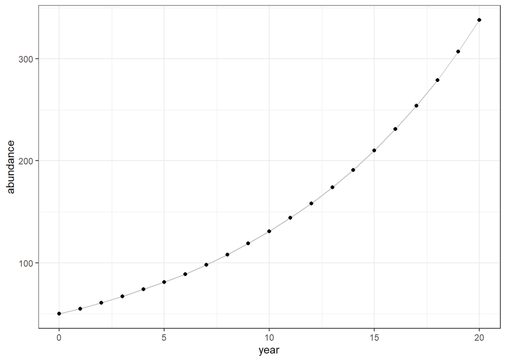

```r
data =
  tibble(
    year = 0:20,
    abundance = N_vector
  )

plot =
  data |>
  ggplot(aes(year, abundance)) +
  geom_line(color = 'grey') +
  geom_point()

plot
```

As we can see, the model predicts that the population will grow in an accelerated fashion every year. We will have much more to say about population growth in the next few weeks.

**Q23. Modify the code above to see what happens to the population when we change the growth rate to $\lambda = 0.9$. Make a plot and show it in your answer.**

This simple exercise illustrates how we can use R to study ecological questions. In the upcoming modules of the class, our focus will shift towards the ecological topics, and R will be our tool for exploring those topics.

## Random variables

Many processes in nature are best described as *stochastic*, meaning they contain an element of randomness. A textbook example of a stochastic process is a coin toss. Other examples in science include radiation, cancer development, and yes, ecological processes.

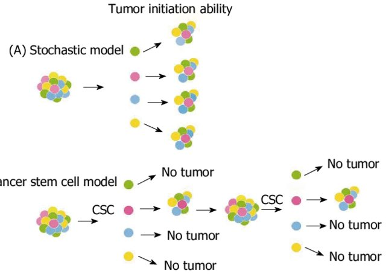

*Figure: Diagramatic representation of a stochastic model of tumor development, from* [Fanali et al. 2014](https://www.wjgnet.com/1007-9327/full/v20/i4/923.htm)

To simulate stochastic processes, all computer languages must have ways of generating random numbers. R is no exception. In R, you can generate a random number between 0 and 1 using the function `runif()`

```r
runif(1)
```

```
## [1] 0.5918192
```

In general, you can generate *n* random numbers between *a* and *b* by specifying the parameters of the function `runif`:

```r
runif(n = 10, min = -5, max = 6)
```

```
##  [1] -3.4469352 -4.0992180 -4.1197441 -0.5891056 -3.1801808  0.9600169
##  [7]  4.9691437  3.6262118 -1.9322390  4.4679605
```

Notice that if you repeat the experiment, you won’t obtain the same random numbers:

```r
runif(n = 10, min = -5, max = 6)
```

```
##  [1] -0.3251004  4.2651135 -3.4903131  2.5849608  1.5720195  4.1193440
##  [7]  2.5126577 -4.6395313  1.9221176 -4.2509683
```

However, it is also useful for the purposes of reproducible research to control the generation of random numbers. In other words, we might want our random numbers to be random but also replicable. To do that, we can use a function called `set.seed()`. Watch this:

```r
set.seed(0)
runif(n = 10, min = -5, max = 6)
```

```
##  [1]  4.8636692 -2.0794047 -0.9066371  1.3013870  4.9902857 -2.7814988
##  [7]  4.8822865  5.3914280  2.2687757  1.9202545
```

```r
set.seed(0)
runif(n = 10, min = -5, max = 6)
```

```
##  [1]  4.8636692 -2.0794047 -0.9066371  1.3013870  4.9902857 -2.7814988
##  [7]  4.8822865  5.3914280  2.2687757  1.9202545
```

Once you set the “seed”, every random number generated afterwards will be determined. Therefore, you and I can get the same random numbers in our respective computers by setting the seed at the top of our R code.

**Note:** If you are wondering how random numbers can be determined in any way, you are on to something! *Truly* random numbers can’t be reproducible by definition. Computer languages like R use so-called *pseudorandom* numbers. If you are curious, check out this accessible [YouTube video](https://www.youtube.com/watch?v=C82JyCmtKWg) explaining pseudorandom numbers and how computers generate them. But for the purposes of this course, all you need to know is that we can control the production of our random numbers by calling the function `set.seed()` with a specified value to its argument (I used 0 in the example above but we could have used any number).

R can also pick random numbers from a specified set using function `sample()`:

```r
sample(c(1, 0, -3, 7, 5), size = 10, replace = TRUE)
```

```
##  [1]  0 -3 -3  1  5  5  0  0  1  5
```

R can also use specific probability distributions to generate random numbers. For example, the function `rnorm()` draws random numbers following a normal distribution:

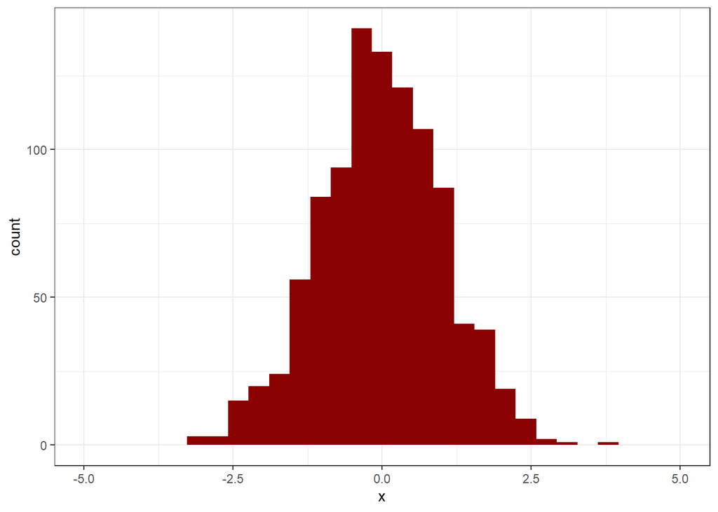

```r
set.seed(1)

random_numbers = rnorm(n = 1000, mean = 0, sd = 1)

random_data =
  tibble(
    x = random_numbers
  )

plot_data =
  random_data |>
  ggplot(aes(x)) +
  geom_histogram(bins = 30, fill = 'darkred') +
  xlim(c(-5, 5))

plot_data
```

The code above first sets the seed to 1, then draws 1000 random numbers from a normal distribution, then puts them in a tibble, and finally draws a histogram with 30 bins.

**Note:** The verb `xlim` piped into `plot_data` simply fixes the range of plotted values in the figure (by default R will use a range that contains the whole data without leaving unnecessary white space).

As you may have guessed, the arguments `mean` and `sd` in `rnorm()` control the mean and standard deviation across the random numbers we drew. The histogram above confirms that indeed our random numbers are centered around 0.

**Q24. Copy/paste the code chunk above, this time setting `sd = 0.4` inside `rnorm`. Plot your histogram and include it in your answer. What differences do you observe?**

**Note:** Don’t worry if you don’t know much about probability distributions and random numbers. It is fine if you couldn’t understand every detail in this section. The goal here is that you feel like you have a sense of what the code is doing.

If by the end of this lab,

- You know how to use RMarkdown to fill out your lab assignment and produce an output PDF file that you can post to Blackboard,
- R code doesn’t read like Greek to you,

Then you are in good shape for later labs.